# G920_Lab7_Fastovich

David Fastovich

October 25, 2018

### 2

#### Loading necessary packages

```r
library(vegan)
library(palaeoSig)
```

#### Applying CA to arctic pollen data

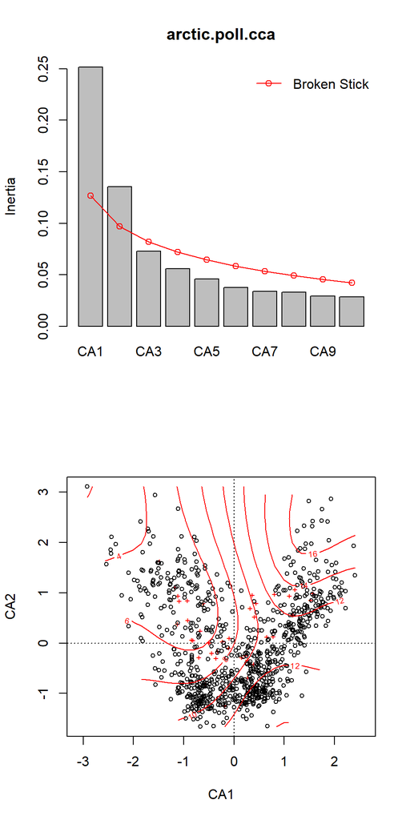

```
##
## Family: gaussian
## Link function: identity
##
## Formula:
## y ~ s(x1, x2, k = 10, bs = "tp", fx = FALSE)
##
## Estimated degrees of freedom:
## 8.84  total = 9.84
##
## REML score: 1699.243
```

```r
data("arctic.pollen") # Loading in arctic pollen data
data("arctic.env") # Loading in arctic environmental data for the ordination surfaces
sq.arctic.poll <- sqrt(arctic.pollen) # Square root transforming the pollen data
arctic.poll.cca <- cca(sq.arctic.poll) # Performing the correspondence analysis
par(mfrow = c(2, 1))
screeplot(arctic.poll.cca, bstick = TRUE) # Plotting a screeplot
plot(arctic.poll.cca) # Making a joint plot
ordisurf(arctic.poll.cca, arctic.env$tjul, add = TRUE) # Adding ordination surface for July temperature
```

- According to the screeplot the first two correspondence axes are significant when compared to a broken stick null model.
- CA1 explains 22% of the variance
- CA2 explains 11% of the variance
- The joint plot indicates that a large portion of sites share a similar environmental variable in CA2, as there is little change in CA2 near a CA1 value of 0. This is not true of CA1 where the sites appear to be following a smooth gradient, with less sites having similar CA1 values. The two axes on the CA joint plot are likely temperature (CA1) and precipitation (CA2).
- There is an arch in the joint plot which indicates that only axis 1 should be interpreted.

#### Because there is an arch CA2 and CA3 will be used in a joint plot

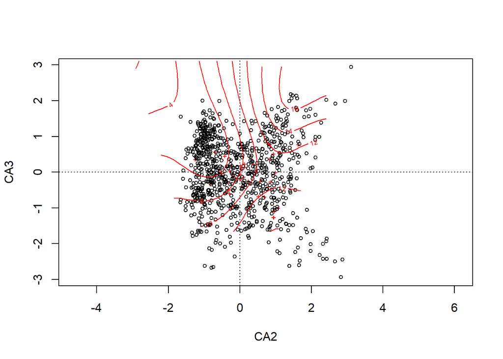

```
##
## Family: gaussian
## Link function: identity
##
## Formula:
## y ~ s(x1, x2, k = 10, bs = "tp", fx = FALSE)
##
## Estimated degrees of freedom:
## 8.84  total = 9.84
##
## REML score: 1699.243
```

```r
plot(arctic.poll.cca, choices = c(2, 3)) # Plotting CA2 and CA3
ordisurf(arctic.poll.cca, arctic.env$tjul, add = TRUE) # Adding ordination surface for July temperature
```

- The joint plot of CA2 and CA3 does not have a similar arch effect. Sites with large CA2 values likely represent the extremes of an environmental gradiant, perhaps precipitation.

### 3

#### Writing my own RDA function

```r
redund <- function(y, x) {
  fit.vals <- matrix(nrow = nrow(y), ncol = ncol(y), data = NA)
  resids <- matrix(nrow = nrow(y), ncol = ncol(y), data = NA)
  for (i in 1:ncol(y)) {
    reg <- lm(y[,i] ~ x)
    fit.vals[,i] <- reg$fitted.values
    resids[,i] <- reg$residuals
  }
  fit.cov <- cov(fit.vals)
  fit.eigen <- eigen(fit.cov)
  resid.cov <- cov(resids)
  resid.eigen <- eigen(resid.cov)
  rda.axis <- fit.eigen$values[1]
  names(rda.axis) <- "RDA1"
  pca.axes <- resid.eigen$values[1:ncol(y)]
  for (i in 1:ncol(y)) {
    nam <- paste("PCA", i, sep = "")
    names(pca.axes)[i] <- nam
  }
  var <- data.frame(Inertia = c((sum(rda.axis, pca.axes)), rda.axis, sum(pca.axes)),
             Proportion = c((sum(rda.axis, pca.axes)/sum(rda.axis, pca.axes)), (sum(rda.axis)/sum(rda.axis, pca.axes)), (sum(pca.axes)/sum(rda.axis, pca.axes))),
             Rank = c("", 1, ncol(y)))
  rownames(var) <- c("Total", "Constrained", "Unconstrained")
  print(var)
  cat("\nEigenvalues for constrained axes:\n")
  print(rda.axis)
  cat("\nEigenvalues for unconstrained axes:\n")
  print(pca.axes)
  return(invisible(c(rda.axis, pca.axes)))
}

redund(y = sq.arctic.poll, x = arctic.env$tave) # My function
```

```
##                 Inertia Proportion Rank
## Total         27.109272  1.0000000
## Constrained    2.863051  0.1056115    1
## Unconstrained 24.246221  0.8943885   39
##
## Eigenvalues for constrained axes:
##     RDA1
## 2.863051
##
## Eigenvalues for unconstrained axes:
##         PCA1         PCA2         PCA3         PCA4         PCA5
## 10.355425270  4.322203374  1.854683860  1.642046167  1.396733889
##         PCA6         PCA7         PCA8         PCA9        PCA10
##  0.992140267  0.710082855  0.479740006  0.364489846  0.251922522
##        PCA11        PCA12        PCA13        PCA14        PCA15
##  0.226922238  0.176031287  0.150828535  0.135039613  0.126723235
##        PCA16        PCA17        PCA18        PCA19        PCA20
##  0.119296857  0.100781992  0.083668467  0.082614269  0.078348381
##        PCA21        PCA22        PCA23        PCA24        PCA25
##  0.073929549  0.064708836  0.061483515  0.056023731  0.046507471
##        PCA26        PCA27        PCA28        PCA29        PCA30
##  0.044084350  0.038035792  0.032215743  0.029434420  0.022906425
##        PCA31        PCA32        PCA33        PCA34        PCA35
##  0.020060169  0.018842781  0.016996990  0.016596175  0.014858102
##        PCA36        PCA37        PCA38        PCA39
##  0.013946697  0.011378527  0.009866808  0.004622215
```

```r
rda(sq.arctic.poll ~ arctic.env$tave) # Function in the vegan package
```

```
## Call: rda(formula = sq.arctic.poll ~ arctic.env$tave)
##
##               Inertia Proportion Rank
## Total         27.1093     1.0000
## Constrained    2.8631     0.1056    1
## Unconstrained 24.2462     0.8944   39
## Inertia is variance
##
## Eigenvalues for constrained axes:
##   RDA1
## 2.8631
##
## Eigenvalues for unconstrained axes:
##    PC1    PC2    PC3    PC4    PC5    PC6    PC7    PC8
## 10.355  4.322  1.855  1.642  1.397  0.992  0.710  0.480
## (Showed only 8 of all 39 unconstrained eigenvalues)
```

Code above verifies that my function returns the same values as the `rda` function in `vegan`. Feel free to test it with other data - it should work just fine.